# Tutorium-11-06-PreProj-Part3-Prediction

dzt

6/10/2021

So far, the basic structure of prediction for project completes. Of course, there are many other unshown ways to improve the outcome in details, that is the point to use your own fantasie to discover it. Note,individual’s outcome should be different.

New Thema:

-Train, Test division : sample_slice(), anti_join() -Prediction: predict() -Hand over

# 1 Daten import

```r
library(readr)
research <- read_csv("https://raw.githubusercontent.com/sebastiansauer/willingness-vaccination-covid19/main/data/d3.csv")
```

# 2 Dataset division in Train and Test

Train: where create the model Test: where test the model

```r
library(dplyr)
train <-  slice_sample(research, prop=.75)
train
```

```
## # A tibble: 123 x 23
##    timestamp     willingness health  fear cases extra1 agree1 cons1 neuro1 open1
##    <chr>               <dbl>  <dbl> <dbl> <dbl>  <dbl>  <dbl> <dbl>  <dbl> <dbl>
##  1 27/04/2021 0…           6     10     1     2      4      3     4      3     4
##  2 23/04/2021 1…          10     10     6     1      2      2     2      3     2
##  3 29/04/2021 1…           1     10     1     4      4      3     3      4     5
##  4 26/04/2021 0…          10      9     3     4      3      4     4      4     4
##  5 23/04/2021 2…          10     10     3     4      5      2     2      4     2
##  6 23/04/2021 1…           8      8     6     1      2      2     2      2     5
##  7 25/04/2021 1…           5     10     1    50      2      5     5      4     5
##  8 29/04/2021 1…           9      9     7     1      4      4     2      3     2
##  9 01/05/2021 1…          10     10     5     8      4      4     2      4     4
## 10 24/04/2021 0…          10      7     2     1      2      2     4      4     1
## # … with 113 more rows, and 13 more variables: extra2 <dbl>, agree2 <dbl>,
## #   cons2 <dbl>, neuro2 <dbl>, open2 <dbl>, age <dbl>, sex <chr>,
## #   comments <chr>, extra <dbl>, agree <dbl>, neuro <dbl>, cons <dbl>,
## #   open <dbl>
```

```r
test <- anti_join(research, train, by="timestamp")
test
```

```
## # A tibble: 41 x 23
##    timestamp     willingness health  fear cases extra1 agree1 cons1 neuro1 open1
##    <chr>               <dbl>  <dbl> <dbl> <dbl>  <dbl>  <dbl> <dbl>  <dbl> <dbl>
##  1 23/04/2021 1…          10      9     5     1      2      2     3      2     4
##  2 23/04/2021 1…           9      9     7     3      3      5     2      3     4
##  3 23/04/2021 1…           9      9     7     3      3      5     2      3     4
##  4 23/04/2021 1…           9      9     3     2      1      3     1      3     4
##  5 23/04/2021 1…           7     10     2     0      3      5     2      5     3
##  6 23/04/2021 1…           1     10     1    10      5      3     5      1     5
##  7 23/04/2021 1…          10     10     8     4      3      3     4      3     4
##  8 23/04/2021 1…           9     10     7     1      2      4     2      2     4
##  9 23/04/2021 1…           8      9     3     2      2      4     3      4     4
## 10 23/04/2021 2…           2     10     3     0      4      5     3      2     4
## # … with 31 more rows, and 13 more variables: extra2 <dbl>, agree2 <dbl>,
## #   cons2 <dbl>, neuro2 <dbl>, open2 <dbl>, age <dbl>, sex <chr>,
## #   comments <chr>, extra <dbl>, agree <dbl>, neuro <dbl>, cons <dbl>,
## #   open <dbl>
```

# 3 Check the missing number

```r
library(skimr)
skim(train)
```

Data summary

| Name | train |
| --- | --- |
| Number of rows | 123 |
| Number of columns | 23 |
| _______________________ |  |
| Column type frequency: |  |
| character | 3 |
| numeric | 20 |
| ________________________ |  |
| Group variables | None |

**Variable type: character**

| skim_variable | n_missing | complete_rate | min | max | empty | n_unique | whitespace |
| --- | --- | --- | --- | --- | --- | --- | --- |
| timestamp | 0 | 1.00 | 19 | 19 | 0 | 123 | 0 |
| sex | 0 | 1.00 | 4 | 6 | 0 | 3 | 0 |
| comments | 120 | 0.02 | 9 | 18 | 0 | 3 | 0 |

**Variable type: numeric**

| skim_variable | n_missing | complete_rate | mean | sd | p0 | p25 | p50 | p75 | p100 | hist |
| --- | --- | --- | --- | --- | --- | --- | --- | --- | --- | --- |
| willingness | 0 | 1.00 | 7.96 | 2.71 | 1.0 | 7.00 | 9.0 | 10.0 | 10 | ▁▁▁▂▇ |
| health | 0 | 1.00 | 9.40 | 1.09 | 4.0 | 9.00 | 10.0 | 10.0 | 10 | ▁▁▁▁▇ |
| fear | 0 | 1.00 | 4.74 | 2.37 | 1.0 | 3.00 | 5.0 | 7.0 | 10 | ▆▆▇▆▁ |
| cases | 0 | 1.00 | 5.43 | 5.89 | 0.0 | 2.00 | 5.0 | 6.0 | 50 | ▇▁▁▁▁ |
| extra1 | 0 | 1.00 | 3.17 | 1.14 | 1.0 | 2.00 | 3.0 | 4.0 | 5 | ▂▆▇▇▃ |
| agree1 | 0 | 1.00 | 3.07 | 1.06 | 1.0 | 2.00 | 3.0 | 4.0 | 5 | ▂▆▇▆▂ |
| cons1 | 0 | 1.00 | 3.12 | 1.25 | 1.0 | 2.00 | 3.0 | 4.0 | 5 | ▃▇▇▇▅ |
| neuro1 | 0 | 1.00 | 3.18 | 1.02 | 1.0 | 2.00 | 3.0 | 4.0 | 5 | ▁▆▆▇▂ |
| open1 | 0 | 1.00 | 3.75 | 1.18 | 1.0 | 3.00 | 4.0 | 5.0 | 5 | ▁▃▅▇▇ |
| extra2 | 0 | 1.00 | 3.56 | 1.10 | 1.0 | 3.00 | 4.0 | 4.0 | 5 | ▁▃▇▇▆ |
| agree2 | 0 | 1.00 | 3.12 | 1.11 | 1.0 | 2.00 | 3.0 | 4.0 | 5 | ▂▅▇▇▂ |
| cons2 | 0 | 1.00 | 3.79 | 0.80 | 2.0 | 3.00 | 4.0 | 4.0 | 5 | ▁▃▁▇▂ |
| neuro2 | 0 | 1.00 | 3.06 | 1.06 | 1.0 | 2.00 | 3.0 | 4.0 | 5 | ▁▇▇▇▂ |
| open2 | 0 | 1.00 | 4.02 | 0.92 | 2.0 | 4.00 | 4.0 | 5.0 | 5 | ▂▃▁▇▇ |
| age | 2 | 0.98 | 20.40 | 1.98 | 18.0 | 19.00 | 20.0 | 21.0 | 29 | ▇▂▁▁▁ |
| extra | 0 | 1.00 | 3.37 | 1.03 | 1.0 | 2.50 | 3.5 | 4.0 | 5 | ▂▅▅▇▅ |
| agree | 0 | 1.00 | 3.10 | 0.83 | 1.5 | 2.50 | 3.0 | 3.5 | 5 | ▃▂▇▃▁ |
| neuro | 0 | 1.00 | 3.12 | 0.89 | 1.0 | 2.50 | 3.0 | 4.0 | 5 | ▁▇▅▇▂ |
| cons | 0 | 1.00 | 3.46 | 0.87 | 1.5 | 3.00 | 3.5 | 4.0 | 5 | ▂▂▇▅▃ |
| open | 0 | 1.00 | 3.89 | 0.88 | 2.0 | 3.25 | 4.0 | 4.5 | 5 | ▂▂▃▃▇ |

2 age missing

```r
library(dplyr)
train <- select(train, -extra,-agree,-neuro,-cons,-open)
train
```

```
## # A tibble: 123 x 18
##    timestamp     willingness health  fear cases extra1 agree1 cons1 neuro1 open1
##    <chr>               <dbl>  <dbl> <dbl> <dbl>  <dbl>  <dbl> <dbl>  <dbl> <dbl>
##  1 27/04/2021 0…           6     10     1     2      4      3     4      3     4
##  2 23/04/2021 1…          10     10     6     1      2      2     2      3     2
##  3 29/04/2021 1…           1     10     1     4      4      3     3      4     5
##  4 26/04/2021 0…          10      9     3     4      3      4     4      4     4
##  5 23/04/2021 2…          10     10     3     4      5      2     2      4     2
##  6 23/04/2021 1…           8      8     6     1      2      2     2      2     5
##  7 25/04/2021 1…           5     10     1    50      2      5     5      4     5
##  8 29/04/2021 1…           9      9     7     1      4      4     2      3     2
##  9 01/05/2021 1…          10     10     5     8      4      4     2      4     4
## 10 24/04/2021 0…          10      7     2     1      2      2     4      4     1
## # … with 113 more rows, and 8 more variables: extra2 <dbl>, agree2 <dbl>,
## #   cons2 <dbl>, neuro2 <dbl>, open2 <dbl>, age <dbl>, sex <chr>,
## #   comments <chr>
```

# 4 Drop cases with missing values in age

```r
library(tidyr)
train <-
train %>%drop_na(age)

skim(train)
```

Data summary

| Name | train |
| --- | --- |
| Number of rows | 121 |
| Number of columns | 18 |
| _______________________ |  |
| Column type frequency: |  |
| character | 3 |
| numeric | 15 |
| ________________________ |  |
| Group variables | None |

**Variable type: character**

| skim_variable | n_missing | complete_rate | min | max | empty | n_unique | whitespace |
| --- | --- | --- | --- | --- | --- | --- | --- |
| timestamp | 0 | 1.00 | 19 | 19 | 0 | 121 | 0 |
| sex | 0 | 1.00 | 4 | 6 | 0 | 3 | 0 |
| comments | 118 | 0.02 | 9 | 18 | 0 | 3 | 0 |

**Variable type: numeric**

| skim_variable | n_missing | complete_rate | mean | sd | p0 | p25 | p50 | p75 | p100 | hist |
| --- | --- | --- | --- | --- | --- | --- | --- | --- | --- | --- |
| willingness | 0 | 1 | 7.93 | 2.73 | 1 | 7 | 9 | 10 | 10 | ▁▁▂▂▇ |
| health | 0 | 1 | 9.39 | 1.10 | 4 | 9 | 10 | 10 | 10 | ▁▁▁▁▇ |
| fear | 0 | 1 | 4.78 | 2.36 | 1 | 3 | 5 | 7 | 10 | ▅▆▇▆▁ |
| cases | 0 | 1 | 5.46 | 5.93 | 0 | 2 | 5 | 6 | 50 | ▇▁▁▁▁ |
| extra1 | 0 | 1 | 3.18 | 1.14 | 1 | 2 | 3 | 4 | 5 | ▂▆▇▇▃ |
| agree1 | 0 | 1 | 3.08 | 1.05 | 1 | 2 | 3 | 4 | 5 | ▁▆▇▆▂ |
| cons1 | 0 | 1 | 3.14 | 1.25 | 1 | 2 | 3 | 4 | 5 | ▃▇▇▇▅ |
| neuro1 | 0 | 1 | 3.17 | 1.03 | 1 | 2 | 3 | 4 | 5 | ▁▆▆▇▂ |
| open1 | 0 | 1 | 3.74 | 1.18 | 1 | 3 | 4 | 5 | 5 | ▁▃▅▆▇ |
| extra2 | 0 | 1 | 3.58 | 1.09 | 1 | 3 | 4 | 4 | 5 | ▁▃▇▇▆ |
| agree2 | 0 | 1 | 3.12 | 1.11 | 1 | 2 | 3 | 4 | 5 | ▂▅▇▇▂ |
| cons2 | 0 | 1 | 3.79 | 0.80 | 2 | 3 | 4 | 4 | 5 | ▁▃▁▇▂ |
| neuro2 | 0 | 1 | 3.05 | 1.06 | 1 | 2 | 3 | 4 | 5 | ▁▇▇▇▂ |
| open2 | 0 | 1 | 4.02 | 0.92 | 2 | 4 | 4 | 5 | 5 | ▂▃▁▇▇ |
| age | 0 | 1 | 20.40 | 1.98 | 18 | 19 | 20 | 21 | 29 | ▇▂▁▁▁ |

```r
train
```

```
## # A tibble: 121 x 18
##    timestamp     willingness health  fear cases extra1 agree1 cons1 neuro1 open1
##    <chr>               <dbl>  <dbl> <dbl> <dbl>  <dbl>  <dbl> <dbl>  <dbl> <dbl>
##  1 27/04/2021 0…           6     10     1     2      4      3     4      3     4
##  2 23/04/2021 1…          10     10     6     1      2      2     2      3     2
##  3 29/04/2021 1…           1     10     1     4      4      3     3      4     5
##  4 26/04/2021 0…          10      9     3     4      3      4     4      4     4
##  5 23/04/2021 2…          10     10     3     4      5      2     2      4     2
##  6 23/04/2021 1…           8      8     6     1      2      2     2      2     5
##  7 25/04/2021 1…           5     10     1    50      2      5     5      4     5
##  8 29/04/2021 1…           9      9     7     1      4      4     2      3     2
##  9 01/05/2021 1…          10     10     5     8      4      4     2      4     4
## 10 24/04/2021 0…          10      7     2     1      2      2     4      4     1
## # … with 111 more rows, and 8 more variables: extra2 <dbl>, agree2 <dbl>,
## #   cons2 <dbl>, neuro2 <dbl>, open2 <dbl>, age <dbl>, sex <chr>,
## #   comments <chr>
```

# 5 Distribution of output “willingess” variablen

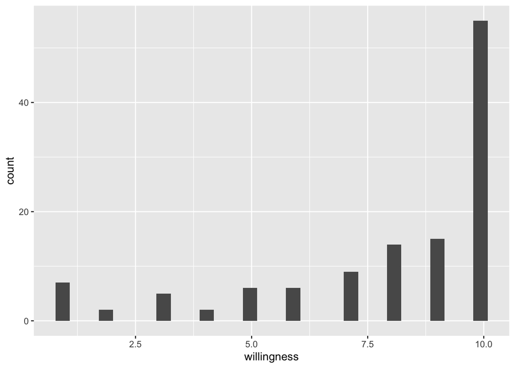

```r
library(ggplot2)
train%>%
ggplot(aes(x=willingness)) + geom_histogram()
```

# 6 Reshaping the data(pivot_longer)

```r
library(tidyverse)
train_pivot <-
select_if(train,is.numeric) %>%  # select only numbers
  pivot_longer(everything(), names_to = "variable")
  # everything() is a convenient shorthand to pivot all variables. pivot_longer(everything()) https://jhudatascience.org/tidyversecourse/wrangle-data.html
train
```

```
## # A tibble: 121 x 18
##    timestamp     willingness health  fear cases extra1 agree1 cons1 neuro1 open1
##    <chr>               <dbl>  <dbl> <dbl> <dbl>  <dbl>  <dbl> <dbl>  <dbl> <dbl>
##  1 27/04/2021 0…           6     10     1     2      4      3     4      3     4
##  2 23/04/2021 1…          10     10     6     1      2      2     2      3     2
##  3 29/04/2021 1…           1     10     1     4      4      3     3      4     5
##  4 26/04/2021 0…          10      9     3     4      3      4     4      4     4
##  5 23/04/2021 2…          10     10     3     4      5      2     2      4     2
##  6 23/04/2021 1…           8      8     6     1      2      2     2      2     5
##  7 25/04/2021 1…           5     10     1    50      2      5     5      4     5
##  8 29/04/2021 1…           9      9     7     1      4      4     2      3     2
##  9 01/05/2021 1…          10     10     5     8      4      4     2      4     4
## 10 24/04/2021 0…          10      7     2     1      2      2     4      4     1
## # … with 111 more rows, and 8 more variables: extra2 <dbl>, agree2 <dbl>,
## #   cons2 <dbl>, neuro2 <dbl>, open2 <dbl>, age <dbl>, sex <chr>,
## #   comments <chr>
```

# 7 Distribution of all predictors

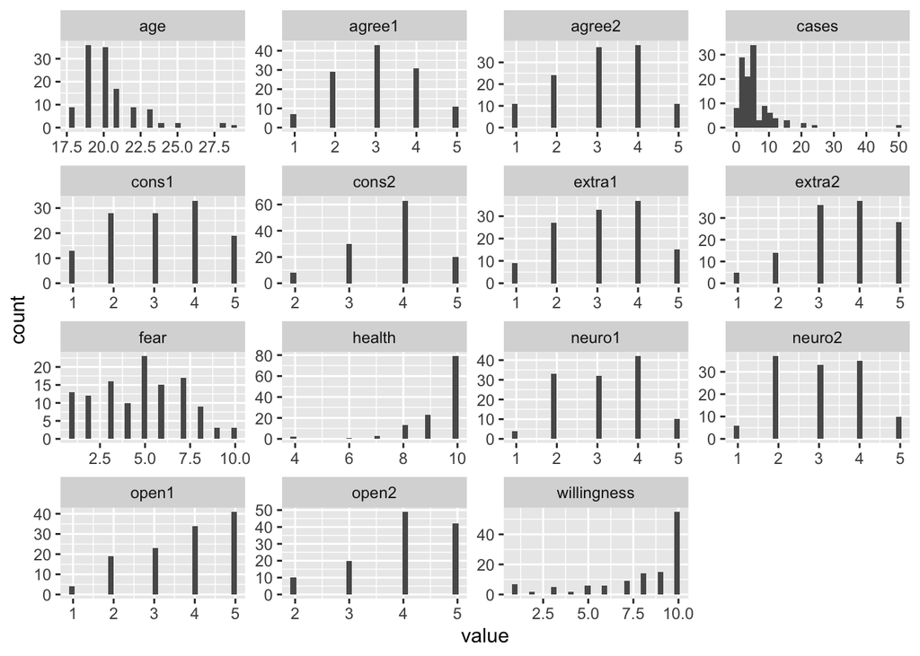

```r
  ggplot(train_pivot,aes(x = value)) +
  geom_histogram() +
  facet_wrap(~ variable, scales = "free")
```

For both the cases variables, the right-skew makes the lower end of the x-axis hard. To make patterns in the data more interpretable and for helping to meet the assumptions of inferential statistics, then need to be transformed

# 8 How to transform data to normal distribution in R?

https://www.datanovia.com/en/lessons/transform-data-to-normal-distribution-in-r/ https://moderndive.com/11-thinking-with-data.html#house-prices-EDA-I 11.3

first try log transformation in a situation where the dependent variable starts to increase more rapidly with increasing independent variable values

log10(x) for positively skewed data, log10(max(x+1) - x) for negatively skewed data

# 9 Transform (via logarithm)

```r
train<- mutate(train,cases_log10=log10(age))
train
```

```
## # A tibble: 121 x 19
##    timestamp     willingness health  fear cases extra1 agree1 cons1 neuro1 open1
##    <chr>               <dbl>  <dbl> <dbl> <dbl>  <dbl>  <dbl> <dbl>  <dbl> <dbl>
##  1 27/04/2021 0…           6     10     1     2      4      3     4      3     4
##  2 23/04/2021 1…          10     10     6     1      2      2     2      3     2
##  3 29/04/2021 1…           1     10     1     4      4      3     3      4     5
##  4 26/04/2021 0…          10      9     3     4      3      4     4      4     4
##  5 23/04/2021 2…          10     10     3     4      5      2     2      4     2
##  6 23/04/2021 1…           8      8     6     1      2      2     2      2     5
##  7 25/04/2021 1…           5     10     1    50      2      5     5      4     5
##  8 29/04/2021 1…           9      9     7     1      4      4     2      3     2
##  9 01/05/2021 1…          10     10     5     8      4      4     2      4     4
## 10 24/04/2021 0…          10      7     2     1      2      2     4      4     1
## # … with 111 more rows, and 9 more variables: extra2 <dbl>, agree2 <dbl>,
## #   cons2 <dbl>, neuro2 <dbl>, open2 <dbl>, age <dbl>, sex <chr>,
## #   comments <chr>, cases_log10 <dbl>
```

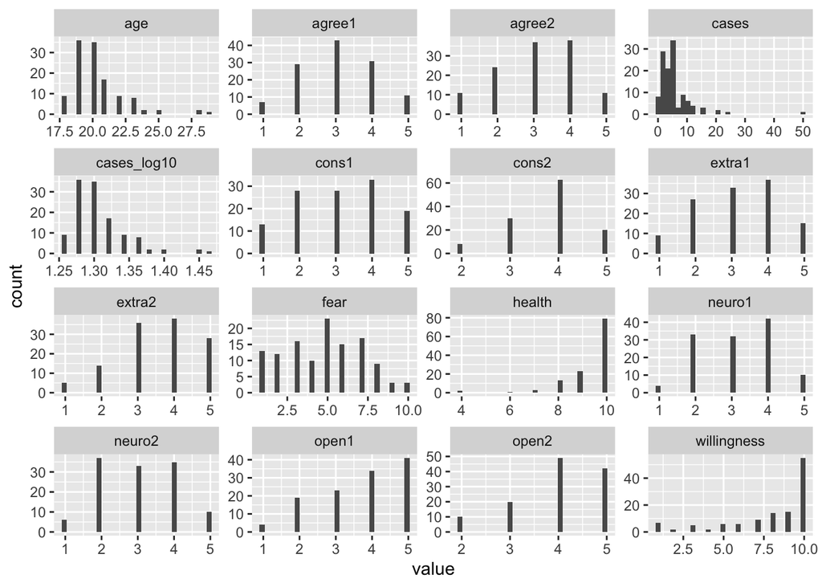

```r
select_if(train,is.numeric) %>%  # select only numbers
  pivot_longer(everything(), names_to = "variable") %>%
  ggplot(aes(x = value)) +
  geom_histogram() +
  facet_wrap(~ variable, scales = "free")#Each axis has a scale
```

# 10 Check outliers

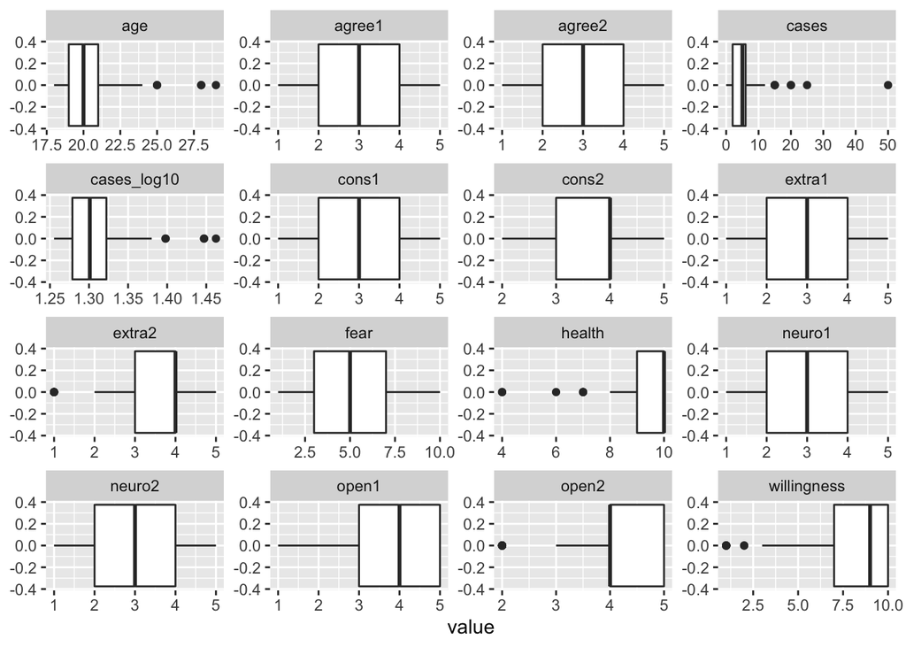

```r
select_if(train,is.numeric) %>%  # select only numbers
  pivot_longer(everything(), names_to = "variable") %>%
  ggplot(aes(x = value)) +
  geom_boxplot() +
  facet_wrap(~ variable, scales = "free")
```

# 11 Find correlation (cormatrix)

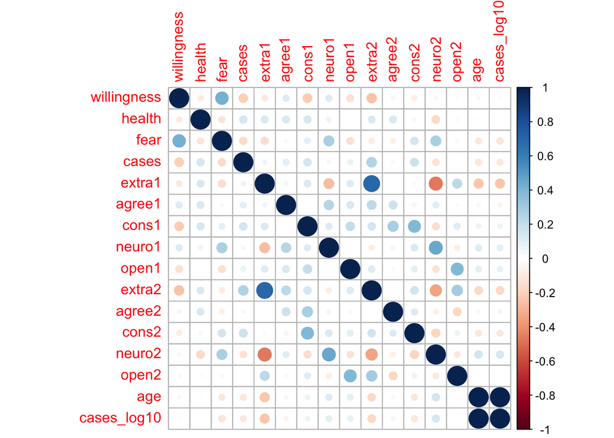

```r
library(corrplot)
train <- select_if(train, is.numeric)
corrplot(cor(train), method = "circle")
```

cases_log10 and age have a strong positive correlation

Creat models, willingness as outcome, to see which variables can be used in model

# 12 Model 1 (step by step)

```r
model1 <- lm(willingness ~ fear, data = train)
```

# 13 Model 2

```r
model2 <- lm(willingness ~ fear+cons1, data = train)
```

# 14 Model 3

```r
model3 <- lm(willingness ~ fear + cons1 + cons2, data = train)
```

# 15 The regsubsets() function (best sample)

(part of the leaps library) performs best subregsubsets() set selection by identifying the best model that contains a given number of predictors, where best is quantified using RSS From: ISLR Book 6.5

```r
library (leaps)
modelfull <- regsubsets (willingness ~.,train)
summary (modelfull)
```

```
## Subset selection object
## Call: regsubsets.formula(willingness ~ ., train)
## 15 Variables  (and intercept)
##             Forced in Forced out
## health          FALSE      FALSE
## fear            FALSE      FALSE
## cases           FALSE      FALSE
## extra1          FALSE      FALSE
## agree1          FALSE      FALSE
## cons1           FALSE      FALSE
## neuro1          FALSE      FALSE
## open1           FALSE      FALSE
## extra2          FALSE      FALSE
## agree2          FALSE      FALSE
## cons2           FALSE      FALSE
## neuro2          FALSE      FALSE
## open2           FALSE      FALSE
## age             FALSE      FALSE
## cases_log10     FALSE      FALSE
## 1 subsets of each size up to 8
## Selection Algorithm: exhaustive
##          health fear cases extra1 agree1 cons1 neuro1 open1 extra2 agree2 cons2
## 1  ( 1 ) " "    "*"  " "   " "    " "    " "   " "    " "   " "    " "    " "
## 2  ( 1 ) " "    "*"  " "   " "    " "    "*"   " "    " "   " "    " "    " "
## 3  ( 1 ) " "    "*"  " "   " "    " "    "*"   " "    " "   "*"    " "    " "
## 4  ( 1 ) " "    "*"  " "   " "    " "    "*"   " "    " "   "*"    " "    " "
## 5  ( 1 ) " "    "*"  " "   " "    "*"    "*"   " "    " "   "*"    " "    " "
## 6  ( 1 ) " "    "*"  " "   "*"    "*"    "*"   " "    " "   "*"    " "    " "
## 7  ( 1 ) " "    "*"  " "   "*"    "*"    "*"   " "    " "   "*"    " "    " "
## 8  ( 1 ) " "    "*"  " "   "*"    "*"    "*"   " "    " "   "*"    " "    " "
##          neuro2 open2 age cases_log10
## 1  ( 1 ) " "    " "   " " " "
## 2  ( 1 ) " "    " "   " " " "
## 3  ( 1 ) " "    " "   " " " "
## 4  ( 1 ) "*"    " "   " " " "
## 5  ( 1 ) "*"    " "   " " " "
## 6  ( 1 ) "*"    " "   " " " "
## 7  ( 1 ) "*"    " "   "*" " "
## 8  ( 1 ) "*"    " "   "*" "*"
```

An asterisk indicates that a given variable is included in the corresponding model. For instance, this output indicates that the best two-variable model contains only fear and cons1. By default, regsubsets() only reports results up to the best eight-variable model

# 16 The regsubsets() function,examine R2, RSS, adjusted R2, Cp, and BIC

```r
reg.summary =summary (modelfull)
names(reg.summary)
```

```
## [1] "which"  "rsq"    "rss"    "adjr2"  "cp"     "bic"    "outmat" "obj"
```

# 17 Check adjust r squared

```r
reg.summary$adjr2
```

```
## [1] 0.1716965 0.2291661 0.2522216 0.2846047 0.3234021 0.3353338 0.3468879
## [8] 0.3629256
```

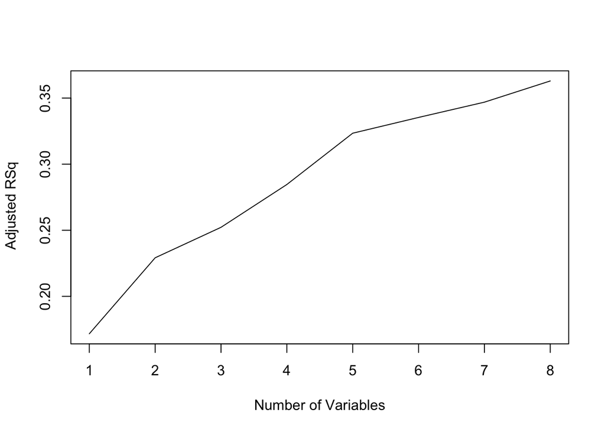

```r
plot(reg.summary$adjr2 ,xlab =" Number of Variables ",
ylab=" Adjusted RSq",type="l")
```

# 18 Confirm model

extra1 extra2

```r
model4 <- lm(willingness ~fear + extra1+ agree1+ cons1 +open1 +extra2  +neuro2 + open2  ,data = train )
```

```r
summary(model4)
```

```
##
## Call:
## lm(formula = willingness ~ fear + extra1 + agree1 + cons1 + open1 +
##     extra2 + neuro2 + open2, data = train)
##
## Residuals:
##     Min      1Q  Median      3Q     Max
## -6.5692 -1.1549  0.3062  1.4376  3.9418
##
## Coefficients:
##             Estimate Std. Error t value Pr(>|t|)
## (Intercept)  8.68967    1.56117   5.566 1.80e-07 ***
## fear         0.57230    0.09115   6.279 6.67e-09 ***
## extra1       0.45554    0.26250   1.735  0.08542 .
## agree1       0.64582    0.20689   3.122  0.00229 **
## cons1       -0.51572    0.17059  -3.023  0.00310 **
## open1       -0.22320    0.19469  -1.146  0.25407
## extra2      -1.12958    0.27361  -4.128 7.06e-05 ***
## neuro2      -0.58469    0.22767  -2.568  0.01154 *
## open2        0.33581    0.25074   1.339  0.18318
## ---
## Signif. codes:  0 '***' 0.001 '**' 0.01 '*' 0.05 '.' 0.1 ' ' 1
##
## Residual standard error: 2.222 on 112 degrees of freedom
## Multiple R-squared:  0.3811, Adjusted R-squared:  0.3368
## F-statistic: 8.619 on 8 and 112 DF,  p-value: 4.218e-09
```

# 19 Confirm model with interaktion

```r
model5 <- lm(willingness ~fear + extra1+ agree1+ cons1 +open1 +extra2  +neuro2 + open2 + fear:cons1+ fear:extra2  ,data = train )
```

```r
summary(model5)
```

```
##
## Call:
## lm(formula = willingness ~ fear + extra1 + agree1 + cons1 + open1 +
##     extra2 + neuro2 + open2 + fear:cons1 + fear:extra2, data = train)
##
## Residuals:
##     Min      1Q  Median      3Q     Max
## -6.6917 -1.1579  0.2515  1.4834  4.0819
##
## Coefficients:
##             Estimate Std. Error t value Pr(>|t|)
## (Intercept) 11.95715    2.04860   5.837 5.46e-08 ***
## fear        -0.14511    0.30707  -0.473  0.63746
## extra1       0.35253    0.26244   1.343  0.18195
## agree1       0.62136    0.20439   3.040  0.00296 **
## cons1       -0.82178    0.35740  -2.299  0.02337 *
## open1       -0.16144    0.19588  -0.824  0.41161
## extra2      -1.76268    0.43653  -4.038  0.00010 ***
## neuro2      -0.53207    0.22816  -2.332  0.02152 *
## open2        0.36403    0.25141   1.448  0.15047
## fear:cons1   0.06302    0.06690   0.942  0.34827
## fear:extra2  0.13759    0.07196   1.912  0.05848 .
## ---
## Signif. codes:  0 '***' 0.001 '**' 0.01 '*' 0.05 '.' 0.1 ' ' 1
##
## Residual standard error: 2.183 on 110 degrees of freedom
## Multiple R-squared:  0.4132, Adjusted R-squared:  0.3599
## F-statistic: 7.747 on 10 and 110 DF,  p-value: 2.712e-09
```

# 20 Prediction

```r
pred <- predict(model5, newdata = test)
pred
```

```
##         1         2         3         4         5         6         7         8
##  9.266587 10.192299 10.192299  6.477897  6.969291  7.250508  9.805435 10.718066
##         9        10        11        12        13        14        15        16
## 10.146259  6.605105  6.209695  6.379278 10.153710  9.723697  4.645626  4.000327
##        17        18        19        20        21        22        23        24
##  5.153833  9.981371  7.943416  7.577047  7.775180  9.778737 11.019900  9.102617
##        25        26        27        28        29        30        31        32
##  9.148562  8.934426  5.949959  5.595704  7.086253  9.106117  6.315994 11.255760
##        33        34        35        36        37        38        39        40
##  6.192344  8.445169  7.529347 10.765226  8.790952  4.383008 10.154125  8.391069
##        41
##  8.370049
```

```r
test2 <- mutate(test, pred)
test2
```

```
## # A tibble: 41 x 24
##    timestamp     willingness health  fear cases extra1 agree1 cons1 neuro1 open1
##    <chr>               <dbl>  <dbl> <dbl> <dbl>  <dbl>  <dbl> <dbl>  <dbl> <dbl>
##  1 23/04/2021 1…          10      9     5     1      2      2     3      2     4
##  2 23/04/2021 1…           9      9     7     3      3      5     2      3     4
##  3 23/04/2021 1…           9      9     7     3      3      5     2      3     4
##  4 23/04/2021 1…           9      9     3     2      1      3     1      3     4
##  5 23/04/2021 1…           7     10     2     0      3      5     2      5     3
##  6 23/04/2021 1…           1     10     1    10      5      3     5      1     5
##  7 23/04/2021 1…          10     10     8     4      3      3     4      3     4
##  8 23/04/2021 1…           9     10     7     1      2      4     2      2     4
##  9 23/04/2021 1…           8      9     3     2      2      4     3      4     4
## 10 23/04/2021 2…           2     10     3     0      4      5     3      2     4
## # … with 31 more rows, and 14 more variables: extra2 <dbl>, agree2 <dbl>,
## #   cons2 <dbl>, neuro2 <dbl>, open2 <dbl>, age <dbl>, sex <chr>,
## #   comments <chr>, extra <dbl>, agree <dbl>, neuro <dbl>, cons <dbl>,
## #   open <dbl>, pred <dbl>
```

# 21 Hand over the result

```r
handover<- select(test2, pred,timestamp)
handover
```

```
## # A tibble: 41 x 2
##     pred timestamp
##    <dbl> <chr>
##  1  9.27 23/04/2021 12:22:18
##  2 10.2  23/04/2021 12:36:17
##  3 10.2  23/04/2021 13:03:06
##  4  6.48 23/04/2021 13:19:00
##  5  6.97 23/04/2021 13:57:17
##  6  7.25 23/04/2021 14:06:58
##  7  9.81 23/04/2021 15:04:24
##  8 10.7  23/04/2021 15:34:54
##  9 10.1  23/04/2021 18:48:04
## 10  6.61 23/04/2021 21:57:54
## # … with 31 more rows
```

```r
write_csv(handover, file = "student name_.csv")
```

Reference:

https://www.youtube.com/watch?v=sdfTaIC8dyE&t=257s https://data-se.netlify.app/2020/11/13/fallstudie-zur-regressionsanalyse-ggplot2movies/#korrelation-zwischen-den-gruppen